# Phage Proteome Analysis

We have proteomics data from three different strains of T7 after 1, 5, and 9 minutes of infection in E. coli. Each time point has 4 replicates. There is an additional replicate done year earlier than the other 4 which is not included in the analyses.

**evolved**: evolved phage with codon-modified gene 10

**recoded**: initial codon-modified gene 10 phage

**wildtype**: wild-type phage

**Normalization:** Data are normalized by total protein area (T7 and E. coli) for each sample *after* computing areas.

### Major capsid protein levels are depressed in recoded and evolved strains

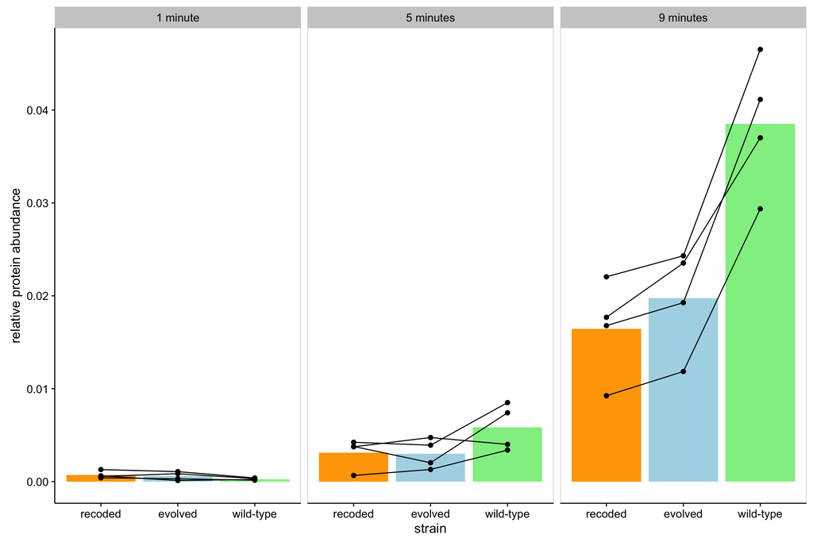

## Phage proteins immediately downstream of 10 are also depressed

### Peak areas

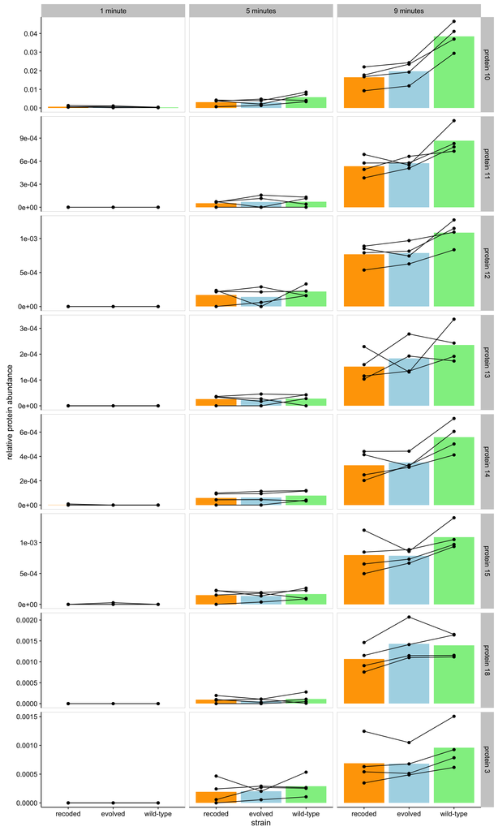

## Which proteins are significantly different across strains?

Looking at the class 3 genes, there seem to be systematic batch effects between biological replicates. For example, replicate 4 might have lower abundances for a given protein in all three strains. I’ve attempted to model this with a mixed effects model:

```r
library(lmerTest)

# Let's just look at the 9min mark without the evolved strain or 10A
all_data2 <- filter(all_data, gene_number != "10", time == "9", strain != "evol", class == 3)

# Build a model with protein abundance as the response, strain and protein as fixed, and biological replicate as random
mod <- lmer(area_norm ~ strain + gene_number + (1 | b_rep), data = all_data2)

anova(mod)
```

```
## Analysis of Variance Table of type III  with  Satterthwaite
## approximation for degrees of freedom
##                 Sum Sq    Mean Sq NumDF DenDF F.value  Pr(>F)
## strain      0.00000249 2.4860e-06     1   150   5.327 0.02236 *
## gene_number 0.00088284 4.4142e-05    20   150  94.581 < 2e-16 ***
## ---
## Signif. codes:  0 '***' 0.001 '**' 0.01 '*' 0.05 '.' 0.1 ' ' 1
```

According to the ANOVA test above, the protein abundances for class 3 genes (excluding 10A) across strains are significantly different. Proteins immediately downstream of 10A (and one protein upstream) are suppressed in the attenuated strain.

| gene_number | estimate | p.value | p.value_adj |
| --- | --- | --- | --- |
| 3 | 2.7e-04 | 0.00014 | 0.0061 |
| 10 | 2.2e-02 | 0.00051 | 0.0110 |
| 13 | 8.4e-05 | 0.00180 | 0.0260 |
| 12 | 3.2e-04 | 0.00590 | 0.0510 |
| 14 | 2.3e-04 | 0.00560 | 0.0510 |
| 11 | 3.3e-04 | 0.00740 | 0.0530 |
| 15 | 2.9e-04 | 0.01400 | 0.0880 |
| 18 | 3.2e-04 | 0.01600 | 0.0880 |

Gene 9, which is expressed roughly at the same time as gene 10A, is not affected by the recoding. The following compares abundances of gene 9 with that of gene 10A.

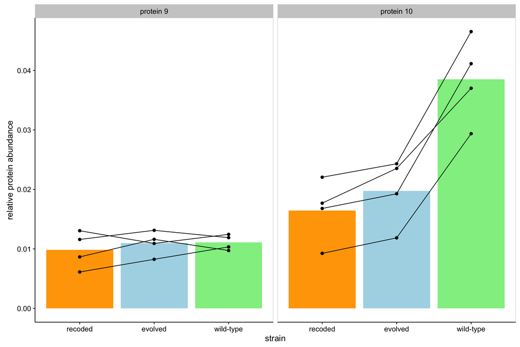